# Joins

This document will go over the basics of using a join to combine one or more data sets as part of an analysis. It assumes that you’ve already gone through the process of creating an ACLED account and [adding your API key to your .Renviron file](https://neilblund.github.io/GVPT429K_Fall24/Slides/acled_vdem.html#using-the-acled-api).

## Setup

We’ll start be loading in the `tidyverse`, `acled.api`, and `vdemdata` packages. We’ll also add the `countrycode` package and `ggrepel` (used just for the last plot). You’ll want to install these with `install.packages` if you don’t have them already.

```r
library(tidyverse) # general data manipulation
library(acled.api) # access to ACLED data
library(vdemdata) # access to V-DEM data
library(countrycode) # tools for matching country names across data sets
```

We’ll start by pulling protest events in the last 90 days, and then use the `count` function to count the number of protest events in each country.

```r
events<-acled.api(
  email.address = Sys.getenv("ACLED_EMAIL"),
  access.key = Sys.getenv("ACLED_API_KEY"),
  start.date = Sys.Date()-90, # today's date - 90
  end.date =Sys.Date(), # function returns today's date
  all.variables = TRUE
)
```

```r
protests<-events|> # filter to only include protests
  filter(event_type =="Protests")|>
  count(country, iso) # count events per country
```

## A simple join

```r
population<-read_csv('https://raw.githubusercontent.com/Neilblund/APAN/refs/heads/main/populations.csv')
```

Now we just need to combine this data with our data that includes counts of protest activity. We’ll do this using a `join` operation ([documentation](https://dplyr.tidyverse.org/reference/mutate-joins.html)). A join is going to take two data sets and combine them by matching on values on a share variable called a “key”.

So, in this case, we’re going to combine our data on global protest events with our data on populations by joining them on their shared [numeric ISO codes](https://en.wikipedia.org/wiki/ISO_3166-1_numeric), which are included in both data sets.

We’ll use a “left join” to combine this data with the data from ACLED. We’ll call the ACLED data the “left hand side” (LHS) data, and the population data the “right hand side” (RHS) data. The left join is going to retain all rows from LHS, and all matching rows from RHS. Any data in RHS that has no match in LHS will be dropped:

[figure not shown]

To to a left join, we’re going to run code like this:

`left_join(LHS, RHS, by=join_by(LHS_key == RHS_key))`.

So here’s how this would work for our current problem:

```r
protests_joined<-left_join(x=protests, y=population, by=join_by(iso == iso))
```

```r
protests_right_joined<-right_join(x=protests, y=population, by=join_by(iso==iso))
```

A right join keeps all rows in the RHS and all matching rows in LHS. As a general rule, I recommend you just always use left joins and place whatever data you want to keep as the left hand side data set.

## Matching countries with different coding schemes

In the previous example, we had a matching ISO country code in both data sets, but there’s no guarantee this will always be the case. For instance, the `V-DEM` data includes country names, a three letter country abbreviation, and `COWcode` from the correlates of war data set, but it doesn’t include a numeric ISO code at all.

```r
vdem<-vdemdata::vdem|>
  filter(year == max(year))

# view the first 10 unique country codes:
vdem|>
  select(COWcode, country_name, country_text_id, country_id)|>
  distinct()|>
  slice_head(n=10)
```

| COWcode | country_name | country_text_id | country_id |
| --- | --- | --- | --- |
| 70 | Mexico | MEX | 3 |
| 115 | Suriname | SUR | 4 |
| 380 | Sweden | SWE | 5 |
| 225 | Switzerland | CHE | 6 |
| 452 | Ghana | GHA | 7 |
| 560 | South Africa | ZAF | 8 |
| 740 | Japan | JPN | 9 |
| 775 | Burma/Myanmar | MMR | 10 |
| 365 | Russia | RUS | 11 |
| 339 | Albania | ALB | 12 |

This is a fairly common problem that you’ll encounter when working with cross-national data. We can try to match based on the country name, but this is often error prone. For instance: “The Dominican Republic” will show up is “Dominican Republic” or “Dominican Republican, The” depending on where you look. Instead, we’ll want to use a standardized system for country identifiers like the ISO codes from the prior example. Unfortunately, there are multiple country ID systems and we’ll often need to convert between them to perform our joins.

The R `countrycode` package will give us a way to translate country codes across different systems so that we can do this kind of join operation. We can supply a country name, a coding scheme, and a destination scheme, and country code will attempt to automatically convert one set of country codes to another. You can view the list of available schemes by running the `codelist` function, or by checking the [package documentation](https://cran.r-project.org/web/packages/countrycode/countrycode.pdf).

```r
codelist|>
  slice_head(n=10)
```

| ar5 | cctld | continent | country.name.de | country.name.de.regex | country.name.en | country.name.en.regex | country.name.fr | country.name.fr.regex | country.name.it | country.name.it.regex | cow.name | cowc | cown | currency | dhs | ecb | eu28 | eurocontrol_pru | eurocontrol_statfor | eurostat | fao | fips | gaul | genc2c | genc3c | genc3n | gwc | gwn | icao.region | … |
| --- | --- | --- | --- | --- | --- | --- | --- | --- | --- | --- | --- | --- | --- | --- | --- | --- | --- | --- | --- | --- | --- | --- | --- | --- | --- | --- | --- | --- | --- | --- |
| ASIA | .af | Asia | Afghanistan | afghan | Afghanistan | afghan | Afghanistan | afghan | Afghanistan | afghan | Afghanistan | AFG | 700 | Afghani | AF | AF | NA | Asia | Asia/Pacific | AF | 2 | AF | 1 | AF | AFG | 004 | AFG | 700 | ASIAPAC | … |
| EIT | .al | Europe | Albanien | albanien | Albania | albania | Albanie | albanie | Albania | albania | Albania | ALB | 339 | Lek | AL | AL | NA | Eurocontrol | ECAC South-East | AL | 3 | AL | 3 | AL | ALB | 008 | ALB | 339 | EUR | … |
| MAF | .dz | Africa | Algerien | algerien | Algeria | algeria | Algérie | alg(e\|é)rie | Algeria | algeria | Algeria | ALG | 615 | Algerian Dinar | NA | DZ | NA | Africa | North-Africa | DZ | 4 | AG | 4 | DZ | DZA | 012 | ALG | 615 | EUR | … |
| ASIA | .as | Oceania | Amerikanisch-Samoa | ^(?=.*amerik).*samoa | American Samoa | ^(?=.*americ).*samoa | Samoa américaines | samoa.*(améric\|americ) | Samoa americane | samoa.*americ | NA | NA | NA | US Dollar | NA | AS | NA | Asia | Asia/Pacific | AS | 5 | AQ | 5 | AS | ASM | 016 | NA | NA | NA | … |
| OECD1990 | .ad | Europe | Andorra | andorra | Andorra | andorra | Andorre | andorr(e\|an) | Andorra | andorra | Andorra | AND | 232 | Euro | NA | AD | NA | NA | NA | AD | 6 | AN | 7 | AD | AND | 020 | NA | NA | NA | … |
| MAF | .ao | Africa | Angola | angola | Angola | angola | Angola | angola | Angola | angola | Angola | ANG | 540 | Kwanza | AO | AO | NA | Africa | Southern-Africa | AO | 7 | AO | 8 | AO | AGO | 024 | ANG | 540 | AFI | … |
| LAM | .ai | Americas | Anguilla | anguill?a | Anguilla | anguill?a | Anguilla | anguill?a | Anguilla | anguill?a | NA | NA | NA | East Caribbean Dollar | NA | AI | NA | Southern America | Mid-Atlantic | AI | 258 | AV | 9 | AI | AIA | 660 | NA | NA | NA | … |
| LAM | .aq | Antarctica | Antarktis | ^(?!.*franz).*antarktis | Antarctica | antarctica | Antarctique | ^(?!.*fran).*antarcti(q\|c) | Antartide | antarcti(q\|c)(?!.*france)\|antarti(c\|de)(?!.*france) | NA | NA | NA | NA | NA | AQ | NA | Asia | Asia/Pacific | AQ | 30 | AY | 10 | AQ | ATA | 010 | NA | NA | NA | … |
| LAM | .ag | Americas | Antigua und Barbuda | antigua | Antigua & Barbuda | antigua | Antigua-et-Barbuda | antigua(.*barbuda)? | Antigua e Barbuda | antigua(.*barbuda)? | Antigua & Barbuda | AAB | 58 | East Caribbean Dollar | NA | AG | NA | Southern America | Mid-Atlantic | AG | 8 | AC | 11 | AG | ATG | 028 | NA | NA | CARSAM | … |
| LAM | .ar | Americas | Argentinien | argentin | Argentina | argentin | Argentine | argentin | Argentina | argentin | Argentina | ARG | 160 | Argentine Peso | NA | AR | NA | Southern America | South-Atlantic | AR | 9 | AR | 12 | AR | ARG | 032 | ARG | 160 | CARSAM | … |

The country code package already includes a mapping for the `vdem` country IDs, so we can remap this to numeric 3-digit ISO codes like this:

```r
vdem$isocode = countrycode(sourcevar = vdem$country_id, # the original country id
                           origin='vdem', # the type of country id,
                           destination ='iso3n' # the type to convert to

                           )
```

Now, we can use another `left_join` operation to combine the ACLED data with the VDEM data using the shared ISO code as a key.

```r
protests_and_vdem<-left_join(protests_joined, vdem,
                             # iso is the column name in the LHS variable,
                             # but we called it isocode in the RHS, so
                             # LHSkey == RHSkey:
                             by = join_by(iso == isocode)
                             )
```

## Putting it all together

Now that we have a data frame with our data sources combined, we can look at the relationships between them in a single analysis.

I’ll create a measure of protests that accounts for population size:

```r
protests_and_vdem<-protests_and_vdem|>
  # protests per 100,000 population:
  mutate(protest_per_cap = n/(population/100000))
```

### Democracy and Protest

And then plot this against the `v2x_polyarchy` variable from V-DEM so I can see how protest activity relates to the level of electoral democracy.

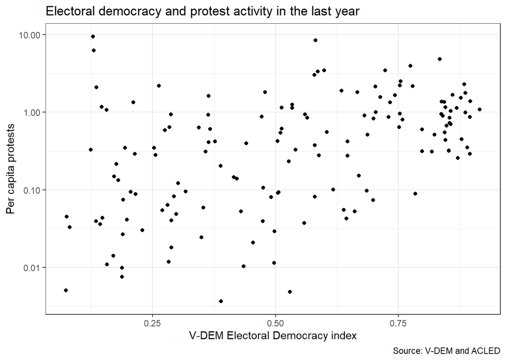

```r
ggplot(protests_and_vdem, aes(x=v2x_polyarchy, y=protest_per_cap)) +
  geom_point() +
  scale_y_log10() +
  ylab("Per capita protests") +
  xlab("V-DEM Electoral Democracy index") +
  labs(title = "Electoral democracy and protest activity in the last year",
       caption = "Source: V-DEM and ACLED"
       ) +
  theme_bw()
```

### Scaled by population size

We can go a bit further and scale this plot by population size:

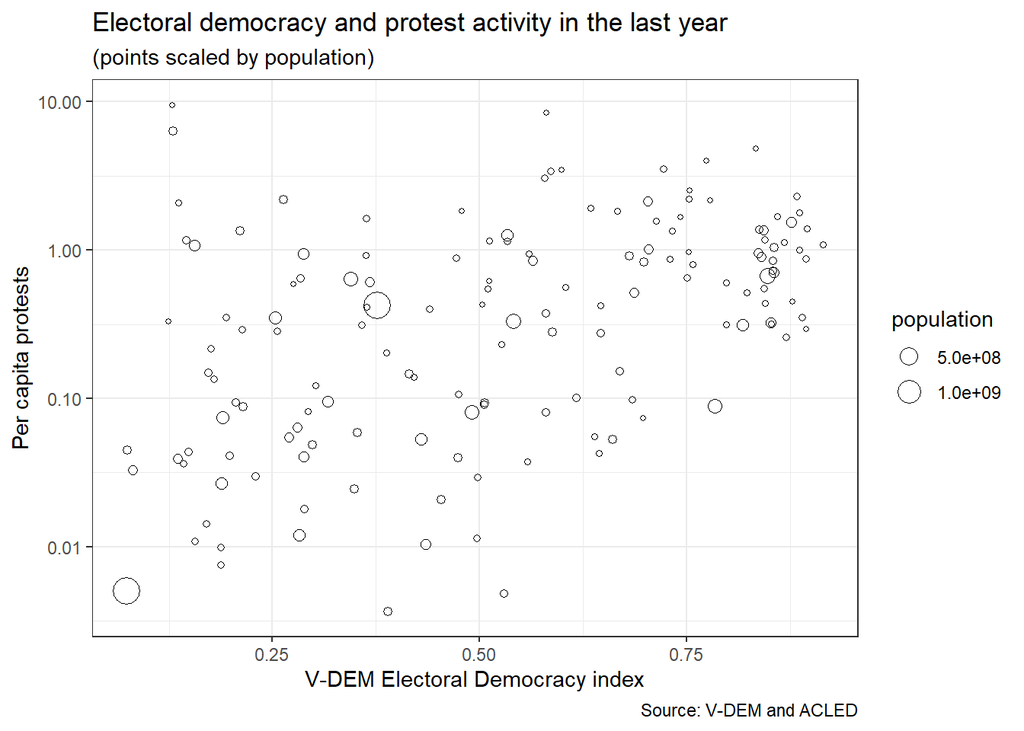

```r
ggplot(protests_and_vdem, aes(x=v2x_polyarchy, y=protest_per_cap)) +
  geom_point(aes(size=population), pch=21) +
  scale_y_log10() +
  ylab("Per capita protests") +
  xlab("V-DEM Electoral Democracy index") +
  labs(title = "Electoral democracy and protest activity in the last year",
       subtitle = "(points scaled by population)",
       caption = "Source: V-DEM and ACLED"
       ) +
  theme_bw()
```

### With country labels

Alternatively, we can label the countries by adding commands from the `ggrepel` package

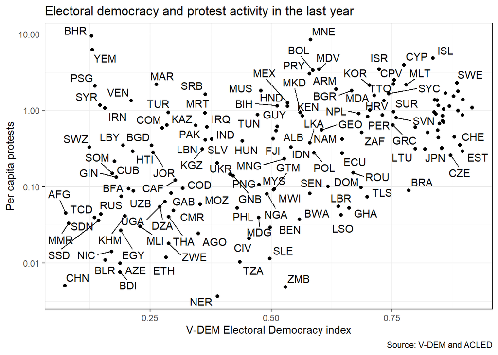

```r
# install.packages('ggrepel')
library(ggrepel)

ggplot(protests_and_vdem, aes(x=v2x_polyarchy, y=protest_per_cap, label=country_text_id)) +
  geom_point() +
  geom_text_repel() +
  scale_y_log10() +
  ylab("Per capita protests") +
  xlab("V-DEM Electoral Democracy index") +
  labs(title = "Electoral democracy and protest activity in the last year",
       caption = "Source: V-DEM and ACLED"
       ) +
  theme_bw()
```

## Joining on multiple keys

There may be cases where you need to join on more than one key. For instance, if I have multiple years of data on protest activity and population I would want to join on both country and the year variable. Fortunately, this is just a matter of adding another key to the “join_by” statement for both data sets.

For example, if I have multiple years of data for North Africa protest activity:

```r
na_events<-acled.api(
  email.address = Sys.getenv("ACLED_EMAIL"),
  access.key = Sys.getenv("ACLED_API_KEY"),
  region = 5,
  all.variables = FALSE,
  add.variables = "iso"
)
```

```r
na_counts<-na_events|>
  filter(event_type =="Protests")|>
  count(country, iso ,year)
```

And multiple years of data from VDEM:

```r
vdem_multiyear<-vdemdata::vdem|>
  filter(year >=1990)

vdem_multiyear$isocode = countrycode(
  sourcevar = vdem_multiyear$country_id,
  # the original country id
  origin = 'vdem',
  # the type of country id,
  destination = 'iso3n' # the type to convert to

)
```

I’ll want to join on `isocode` and the `year` variable from both data sets:

```r
# now join by isocode AND year
na_combined <- left_join(na_counts, vdem_multiyear, by=join_by(iso == isocode,
                                                               year ==year))
```